# Storm Report

lsantric

September 27, 2015

### Synopsis

Storms and other severe weather events can cause both public health and economic problems for communities and municipalities. Many severe events can result in fatalities, injuries, and property damage, and preventing such outcomes to the extent possible is a key concern.

This project involves exploring the U.S. National Oceanic and Atmospheric Administration’s (NOAA) storm database. This database tracks characteristics of major storms and weather events in the United States, including when and where they occur, as well as estimates of any fatalities, injuries, and property damage.

The basic goal of this assignment is to explore the NOAA Storm Database and answer some basic questions about severe weather events.

Data analysis will try to address the following questions:

Across the United States, which types of events (as indicated in the EVTYPE variable) are most harmful with respect to population health?

Across the United States, which types of events have the greatest economic consequences?

### Data Processing

After loading the data from csv file, it is grouped by their type and its impact to population health and property aggregated:

```r
library(data.table)
library(ggplot2)

stormData <- fread("repdata-data-StormData.csv")
stormData <- data.table(stormData)
setkey(stormData, EVTYPE)

fatal <- stormData[,sum(FATALITIES), by=EVTYPE]
setkey(fatal, V1)
setorder(fatal,-V1)
setnames(fatal, c("Type", "Fatalities"))

injury <- stormData[,sum(INJURIES), by=EVTYPE]
setkey(injury, V1)
setorder(injury,-V1)
setnames(injury, c("Type", "Injuries"))

setkey(stormData, PROPDMGEXP)
stormData["K", PROPDMGEXP := "3"]
setkey(stormData, PROPDMGEXP)
stormData["M", PROPDMGEXP := "6"]
setkey(stormData, PROPDMGEXP)
stormData["B", PROPDMGEXP := "9"]
damage <- stormData[,absDMG := PROPDMG * 10 ^ as.numeric(PROPDMGEXP)]
damage <- damage[,sum(absDMG, na.rm = TRUE), by=EVTYPE]
setkey(damage, V1)
setorder(damage,-V1)
setnames(damage, c("Type", "Damage"))
```

### Results

#### Impact on population health

The following r code plots number of injuries and fatalities by eventy type:

```r
head(fatal)
```

```
##              Type Fatalities
## 1:        TORNADO       5633
## 2: EXCESSIVE HEAT       1903
## 3:    FLASH FLOOD        978
## 4:           HEAT        937
## 5:      LIGHTNING        816
## 6:      TSTM WIND        504
```

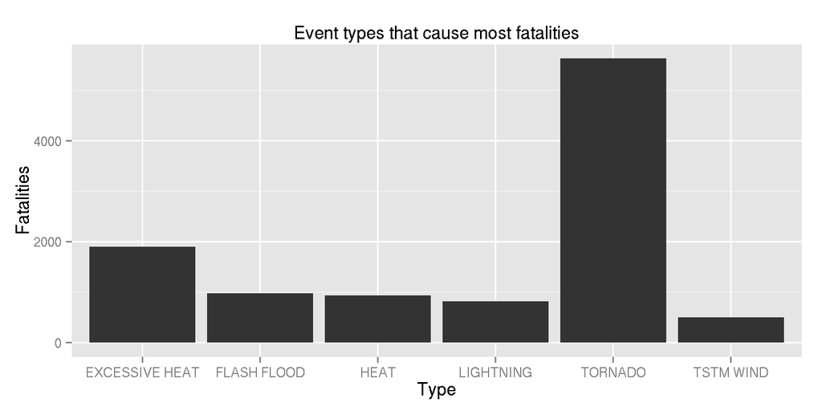

```r
ggplot(data.table(head(fatal)), aes(x=Type, y=Fatalities)) +
  geom_bar(stat="identity") +
  ggtitle("Event types that cause most fatalities")
```

```r
head(injury)
```

```
##              Type Injuries
## 1:        TORNADO    91346
## 2:      TSTM WIND     6957
## 3:          FLOOD     6789
## 4: EXCESSIVE HEAT     6525
## 5:      LIGHTNING     5230
## 6:           HEAT     2100
```

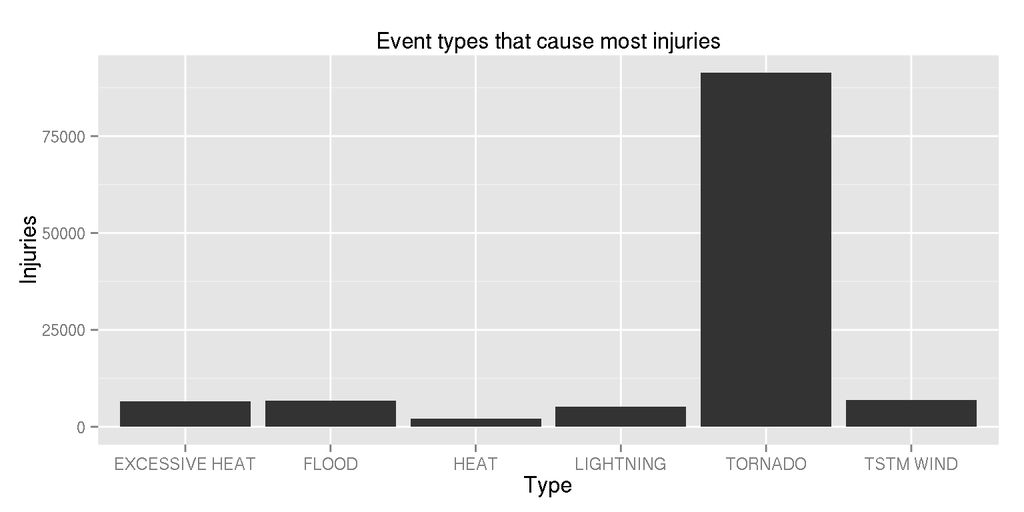

```r
ggplot(data.table(head(injury)), aes(x=Type, y=Injuries)) +
  geom_bar(stat="identity") +
  ggtitle("Event types that cause most injuries")
```

It is clear from the data that tornadoes present greatest threat to the population by far.

#### Impact on property

The following r code plots property damage in dollars by eventy type:

```r
head(damage)
```

```
##                 Type       Damage
## 1:             FLOOD 144657709800
## 2: HURRICANE/TYPHOON  69305840000
## 3:           TORNADO  56935880614
## 4:       STORM SURGE  43323536000
## 5:       FLASH FLOOD  16822673772
## 6:              HAIL  15730366956
```

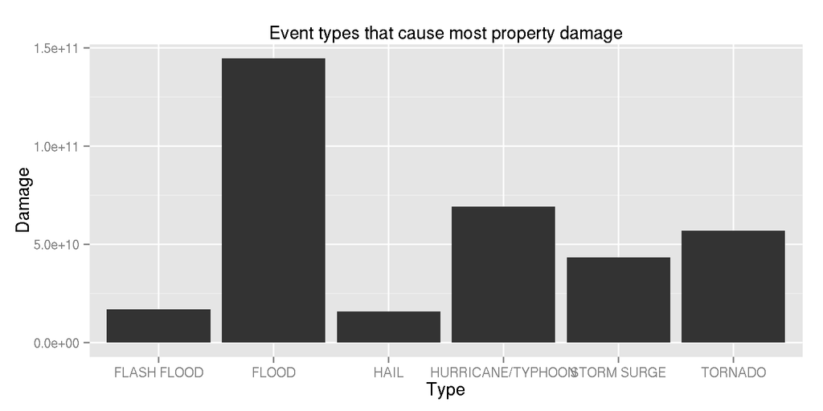

```r
ggplot(data.table(head(damage)), aes(x=Type, y=Damage)) +
  geom_bar(stat="identity") +
  ggtitle("Event types that cause most property damage")
```

Weather events that make most damage to property are floods, hurricanes, tornadoes and storm surges. Floods are responsible the mosts.